# Prior Analysis Jose’s Data and Posteriors

Matt Wheeler

9/22/2020

## Sensitivity Analysis of priors

I am going to look at the different priors and the resulting likelihood that results for the following data-set using maximum likelihood estimation. Note that I have made all of the doses on a (0,1) scale for more appropriate comparisons.

```r
print(mData)
```

```
##       [,1] [,2] [,3]
## [1,] 0.000    1   10
## [2,] 0.075    4   10
## [3,] 0.250    4   10
## [4,] 1.000    7   10
```

```r
H = single_dichotomous_fit(mData[,1],mData[,2],mData[,3],model_type ="weibull",fit_type = "mle")
H$parameters
```

```
## [1] -2.1666034  0.4443281  1.0068814
```

So what happens when we start to mess around with the prior? Well lets see the default prior in `ToxicR’ using MCMC for pretty plots we have:

```r
H = single_dichotomous_fit(mData[,1],mData[,2],mData[,3],model_type = "weibull",fit_type = "mcmc")
print( H$fitted_model$parameters)
```

```
## [1] -1.0913760  1.0051454  0.7630374
```

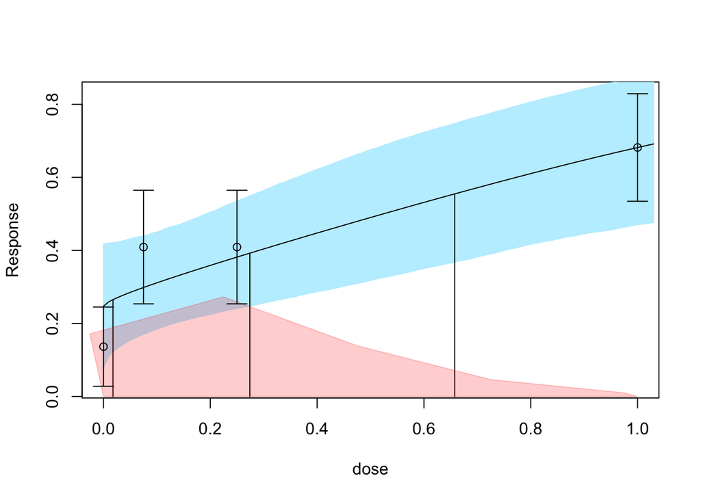

```r
plot(H)
```

```r
H$prior
```

```
## $prior
## Model Parameter Priors
##  ------------------------------------------------------------------------
## Prior: Normal(mu = 0.00, sd = 2.000) 1[-20.00,20.00]
## Prior: Log-Normal(log-mu = 0.42, log-sd = 0.500) 1[0.00,40.00]
## Prior: Log-Normal(log-mu = 0.00, log-sd = 1.500) 1[0.00,10000.00]
```

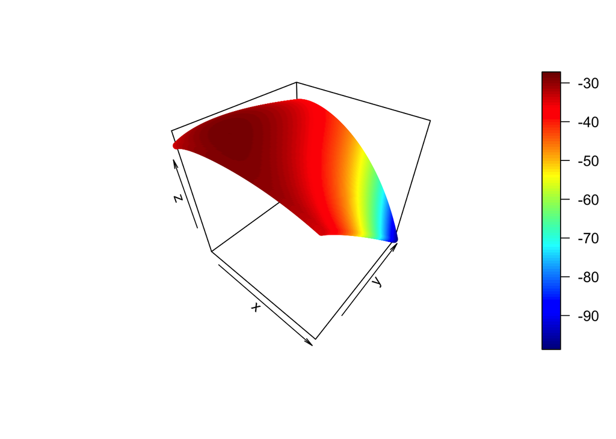

The peak is not noticeably different, so it is essentially performing the same inference.

### Jose’s First Prior

```r
prior <- create_prior_list(normprior(0,2,-20,20),
                           lnormprior(0.5,0.3,0,20),
                           lnormprior(0,1.5,0,10000))
H = single_dichotomous_fit(mData[,1],mData[,2],mData[,3],model_type =   "weibull",fit_type = "mcmc",prior = prior)
print( H$fitted_model$parameters)
```

```
## [1] -0.9061123  1.4451849  0.6808757
```

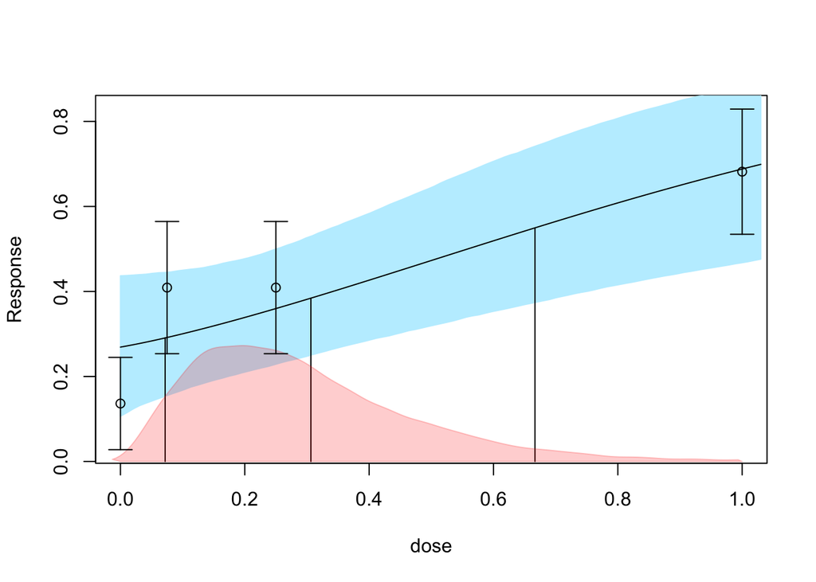

```r
plot(H)
```

```r
H$prior
```

```
## $prior
## Model Parameter Priors
##  ------------------------------------------------------------------------
## Prior: Normal(mu = 0.00, sd = 2.000) 1[-20.00,20.00]
## Prior: Log-Normal(log-mu = 0.50, log-sd = 0.300) 1[0.00,20.00]
## Prior: Log-Normal(log-mu = 0.00, log-sd = 1.500) 1[0.00,10000.00]
```

Here the alpha kicks up to $1.44$ thus our prior is starting to impact our fit. What does this prior surface look like?

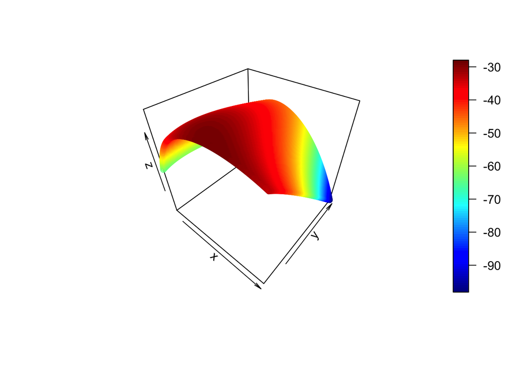

### Jose’s Second prior

Looking at the second prior on the list we can do the same as above.

```r
prior <- create_prior_list(normprior(0,2,-20,20),
                           lnormprior(0.8,0.5,0,20),
                           lnormprior(0,1.5,0,10000))
H = single_dichotomous_fit(mData[,1],mData[,2],mData[,3],model_type =   "weibull",fit_type = "mcmc",prior = prior)
print( H$fitted_model$parameters)
```

```
## [1] -0.8790296  1.5621925  0.6656322
```

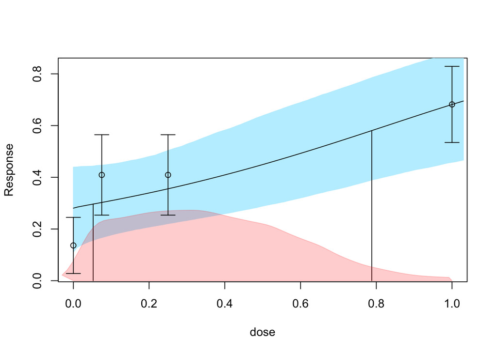

```r
plot(H)
```

```r
H$prior
```

```
## $prior
## Model Parameter Priors
##  ------------------------------------------------------------------------
## Prior: Normal(mu = 0.00, sd = 2.000) 1[-20.00,20.00]
## Prior: Log-Normal(log-mu = 0.80, log-sd = 0.500) 1[0.00,20.00]
## Prior: Log-Normal(log-mu = 0.00, log-sd = 1.500) 1[0.00,10000.00]
```

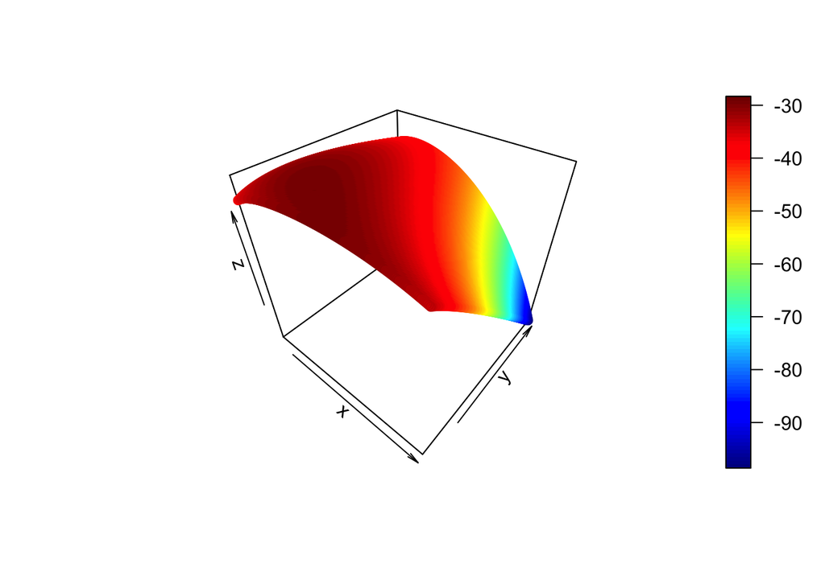

Given there is more variance the ellipsis/quadratic does not move as far but it still moves. The problem is the same as above. There is barely any difference between an $\alpha = 1$ and an $\alpha = 1.4$ as far as inference is concerned.

### Jose’s Third prior

```r
prior <- create_prior_list(normprior(0,2,-20,20),
                           lnormprior(-1,0.2,0,20),
                           lnormprior(0,1.5,0,10000))
H = single_dichotomous_fit(mData[,1],mData[,2],mData[,3],model_type =   "weibull",fit_type = "mcmc",prior = prior)
print( H$fitted_model$parameters)
```

```
## [1] -1.6671302  0.3549661  0.7362700
```

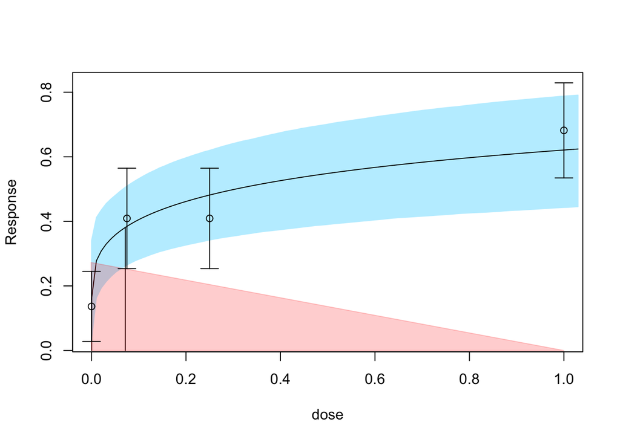

```r
plot(H)
```

```r
H$prior
```

```
## $prior
## Model Parameter Priors
##  ------------------------------------------------------------------------
## Prior: Normal(mu = 0.00, sd = 2.000) 1[-20.00,20.00]
## Prior: Log-Normal(log-mu = -1.00, log-sd = 0.200) 1[0.00,20.00]
## Prior: Log-Normal(log-mu = 0.00, log-sd = 1.500) 1[0.00,10000.00]
```

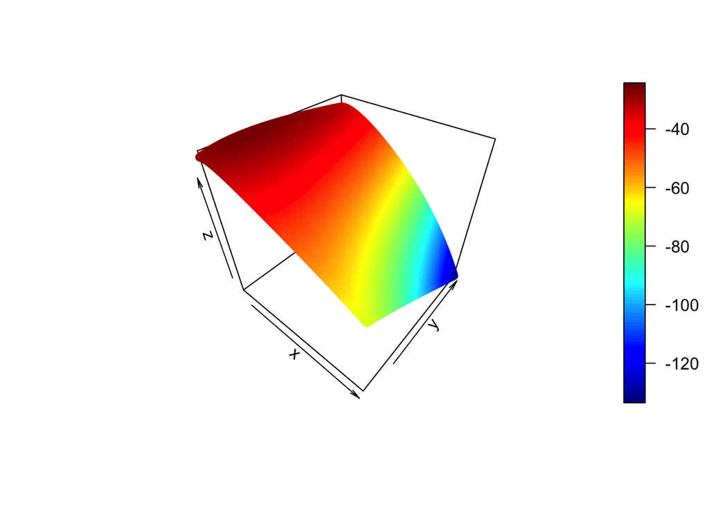

Now this prior is wacky, but it gives the result we would expect. It puts all of the mass of $\alpha$ below 1 and give a nutjob (scientific term) surface to optimize.

### BMDS Standard Prior

```r
prior <- create_prior_list(normprior(0,2,-20,20),
                           lnormprior(0.69,0.42,0,20),
                           lnormprior(0,1.5,0,10000))
H = single_dichotomous_fit(mData[,1],mData[,2],mData[,3],model_type =   "weibull",fit_type = "mcmc",prior = prior)
print( H$fitted_model$parameters)
```

```
## [1] -0.8810978  1.5524636  0.6666730
```

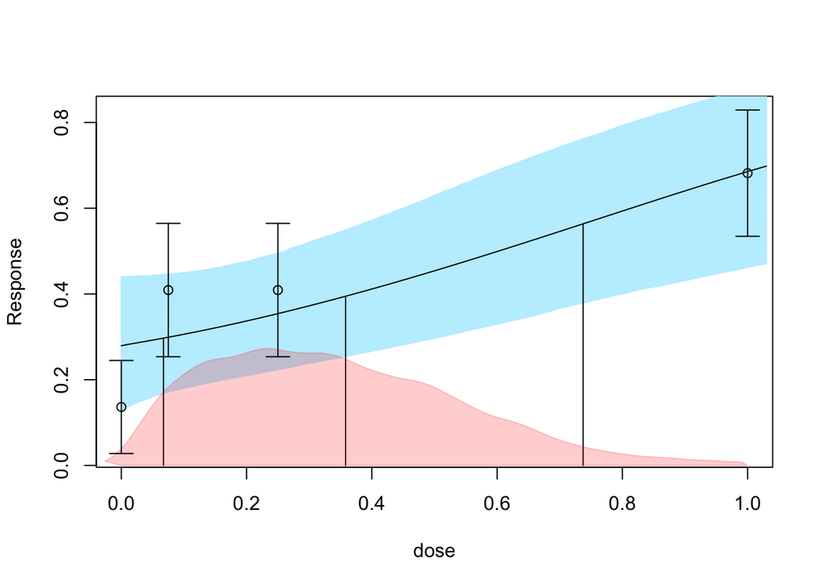

```r
plot(H)
```

```r
H$prior
```

```
## $prior
## Model Parameter Priors
##  ------------------------------------------------------------------------
## Prior: Normal(mu = 0.00, sd = 2.000) 1[-20.00,20.00]
## Prior: Log-Normal(log-mu = 0.69, log-sd = 0.420) 1[0.00,20.00]
## Prior: Log-Normal(log-mu = 0.00, log-sd = 1.500) 1[0.00,10000.00]
```

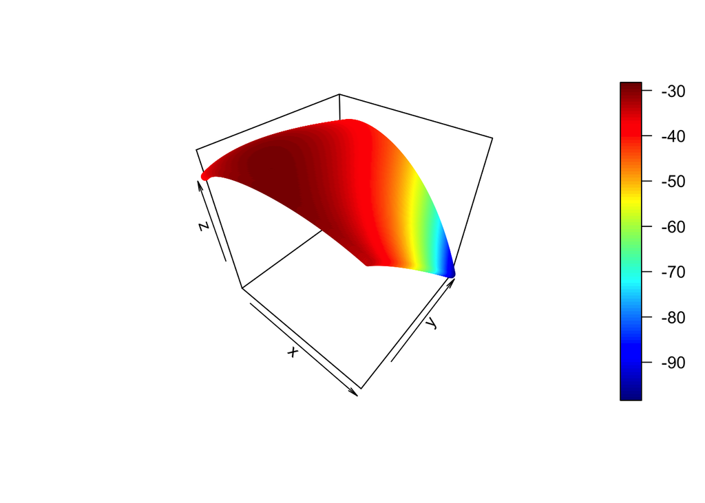

Again, we see that the default BMDS prior puts things in a much more ‘reasonable’ area, because truth be told there is not a heck of a lot of information to put $\alpha$ below zero. In fact a likelihood difference of 0.5 is barely a sneeze. To me, this just shows how little information can be in these data sets that inform our models. As always, being careful is the name of the game.

### Continuous Model Averaging

Jay here is Continuous MA

```r
library(ToxicR)

set.seed(893223)

D <-c(rep(seq(0,1.0,1/4),each=4))
mean <- 2.3  + 10/(1+exp(-(D-0.60)*8))*(1/(1+exp(-(0.99-D)*13)))

Y <- mean + rnorm(length(mean),0,0.7)
#Q <- single_continuous_fit(as.matrix(D),as.matrix(Y),sstat = F,BMR = 1.0 ,model_type="FUNL",distribution = "normal",fit_type = "laplace")

system.time({fit<-ma_continuous_fit(D,Y,fit_type="mcmc",samples=25000,burnin=2500,BMR=2.0)})
```

```
##    user  system elapsed
##  13.573   0.214   1.198
```

```r
system.time({fit2<-ma_continuous_fit(D,Y,fit_type="laplace",BMR=2.0)})
```

```
##    user  system elapsed
##   8.523   0.290   0.896
```

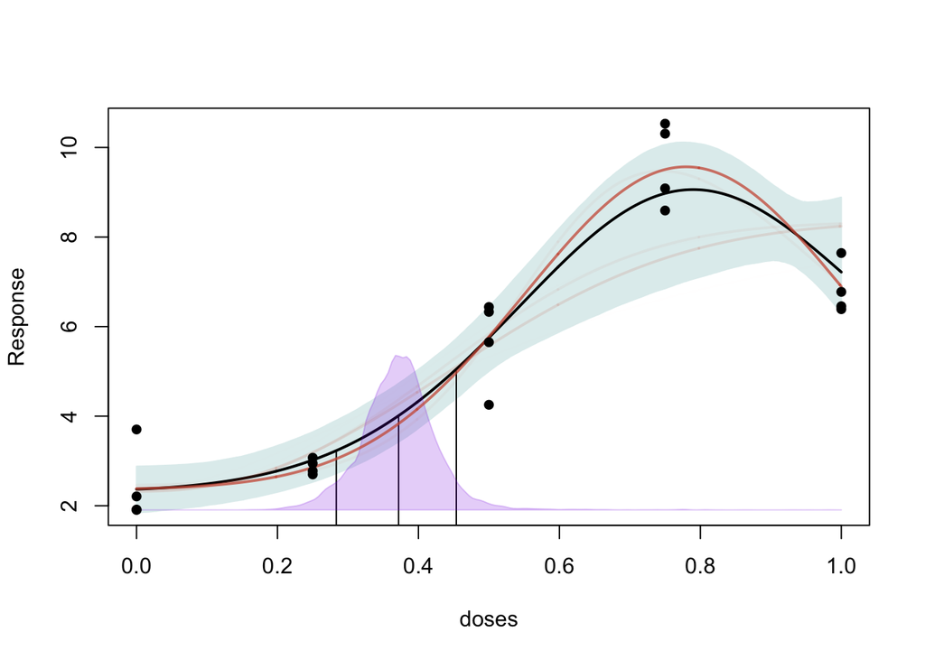

```r
plot(fit)
```